# Stages in ML Project

1. Problem statement/Goal/Objective
2. Data Exploration Validation
3. Data cleaning
4. Model Building and Validation

# [1] Problem Statement

A **credit score** is a numerical representation of an individual's creditworthiness, typically ranging from 300 to 850. It helps lenders assess the risk of lending money to individuals. Higher credit scores indicate better creditworthiness, meaning the individual is more likely to repay loans on time, while lower scores indicate higher risk.

### Key Factors That Determine a Credit Score:

1. **Payment History (35%)**:
   - This is the most significant factor. It includes whether you’ve paid past credit accounts on time. Late payments, defaults, bankruptcies, and foreclosures negatively impact your score.
2. **Credit Utilization (30%)**:
   - This is the ratio of current credit card balances to the total credit limit. It’s recommended to keep credit utilization below 30%. For example, if your total credit limit is $10,000 and your balance is $3,000, your utilization rate is 30%.
3. **Length of Credit History (15%)**:
   - The longer your credit history, the better. This includes the age of your oldest account, the average age of all accounts, and how long it’s been since you used certain accounts.
4. **Credit Mix (10%)**:
   - Having a variety of credit types (e.g., credit cards, mortgages, auto loans) can help your score. It shows you can manage different types of debt.
5. **New Credit (10%)**:
   - Opening several new credit accounts in a short period can negatively impact your score. Each time you apply for credit, a hard inquiry is made, which can lower your score temporarily.

**Credit risk model building** is the process of developing statistical or machine learning models to assess the likelihood that a borrower or customer will default on their financial obligations. These models are essential in banking, lending, and financial services as they help institutions quantify the level of risk associated with granting loans or credit to customers. A critical model within this domain is the **Probability of Default (PD) model**, which estimates the likelihood that a borrower will default on a loan within a specific timeframe, often one year.

Dataset Location - https://github.com/venkatareddykonasani/Datasets/tree/master/Give%20me%20some%20Credit

# [2] Data Exploration and Data Validation

```python
import matplotlib.pyplot as plt
import pandas as pd
import seaborn as sns
```

- **matplotlib**
  - It is a plotting library for creating static, animated, and interactive visualizations in Python.
  - pyplot is a module in matplotlib that provides a MATLAB-like interface for creating plots.
- Use: It is used to create a wide variety of plots like line charts, bar charts, scatter plots, histograms, etc. pandas:
- **pandas**
  - It is a powerful library for data manipulation and analysis.
  - It provides two primary data structures:
    - DataFrame: A 2D labeled data structure, similar to a table.
    - Series: A 1D labeled array.
  - Use: It is used to load, manipulate, and analyze structured data (e.g., CSV, Excel, SQL).
- **seaborn**
  - It is a data visualization library built on top of matplotlib.
  - It provides a high-level interface for drawing attractive and informative statistical graphics.
  - Use: It simplifies the process of creating complex visualizations like heatmaps, violin plots, pair plots, etc., and integrates well with pandas.

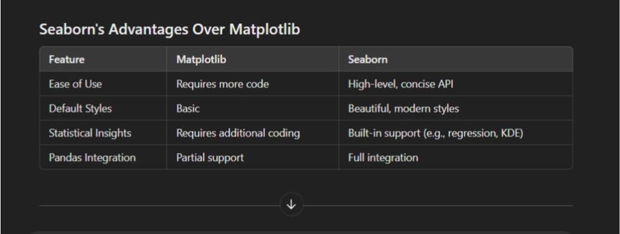

## Import Give me some Credit\cs-training.csv

```python
loans=pd.read_csv("https://raw.githubusercontent.com/venkatareddykonasani/Datasets/master/Give%20me%20some%20Credit/cs-training.csv")
```

Here is a table listing all the methods to read data using pandas, formatted for easy viewing:

| **Method** | **Function** | **Description** | **Common Parameters** |
| --- | --- | --- | --- |
| **CSV** | `pd.read_csv()` | Reads a CSV file. | `delimiter`, `header`, `usecols` |
| **Excel** | `pd.read_excel()` | Reads an Excel file. | `sheet_name`, `usecols`, `header` |
| **JSON** | `pd.read_json()` | Reads a JSON file. | `orient` |
| **SQL** | `pd.read_sql()` | Reads from a SQL database. | `sql`, `con` |
| **HTML** | `pd.read_html()` | Reads tables from an HTML page. | `match`, `flavor` |
| **Text/Flat Files** | `pd.read_csv()` | Reads delimited text files (e.g., TSV). | `delimiter`, `header`, `usecols` |
| **Parquet** | `pd.read_parquet()` | Reads a Parquet file. | `columns`, `engine` |
| **Pickle** | `pd.read_pickle()` | Reads a serialized Python object. | N/A |
| **HDF5** | `pd.read_hdf()` | Reads data from an HDF5 file. | `key`, `mode` |
| **Clipboard** | `pd.read_clipboard()` | Reads data from the clipboard. | `sep` |
| **Feather** | `pd.read_feather()` | Reads a Feather file. | N/A |
| **Stata** | `pd.read_stata()` | Reads a Stata file (`.dta`). | `convert_categoricals`, `columns` |
| **SPSS** | `pd.read_spss()` | Reads an SPSS file (`.sav`). | `usecols`, `convert_categoricals` |
| **ORC** | `pd.read_orc()` | Reads an ORC file. | N/A |
| **XML** | `pd.read_xml()` | Reads an XML file. | `xpath`, `parser` |
| **Avro** | Third-party libraries | Avro files require libraries like `fastavro`. | N/A |

```python
loans.info()
```

```
<class 'pandas.core.frame.DataFrame'>
RangeIndex: 150000 entries, 0 to 149999
Data columns (total 12 columns):
 #   Column                                Non-Null Count   Dtype
---  ------                                --------------   -----
 0   Sr_No                                 150000 non-null  int64
 1   SeriousDlqin2yrs                      150000 non-null  int64
 2   monthly_utilization                   150000 non-null  float64
 3   age                                   150000 non-null  int64
 4   NumberOfTime30-59DaysPastDueNotWorse  150000 non-null  int64
 5   DebtRatio                             150000 non-null  float64
 6   MonthlyIncome                         120269 non-null  float64
 7   NumberOfOpenCreditLinesAndLoans       150000 non-null  int64
 8   NumberOfTimes90DaysLate               150000 non-null  int64
 9   NumberRealEstateLoansOrLines          150000 non-null  int64
 10  NumberOfTime60-89DaysPastDueNotWorse  150000 non-null  int64
 11  NumberOfDependents                    146076 non-null  float64
dtypes: float64(4), int64(8)
memory usage: 13.7 MB
```

```python
#What are number of rows and columns
loans.shape
```

```
(150000, 12)
```

```python
#Are there any suspicious variables?
loans.columns
```

```
Index(['Sr_No', 'SeriousDlqin2yrs', 'monthly_utilization', 'age',
       'NumberOfTime30-59DaysPastDueNotWorse', 'DebtRatio', 'MonthlyIncome',
       'NumberOfOpenCreditLinesAndLoans', 'NumberOfTimes90DaysLate',
       'NumberRealEstateLoansOrLines', 'NumberOfTime60-89DaysPastDueNotWorse',
       'NumberOfDependents'],
      dtype='object')
```

```python
#Display the variable formats
loans.dtypes
```

|  | 0 |
| --- | --- |
| Sr_No | int64 |
| SeriousDlqin2yrs | int64 |
| monthly_utilization | float64 |
| age | int64 |
| NumberOfTime30-59DaysPastDueNotWorse | int64 |
| DebtRatio | float64 |
| MonthlyIncome | float64 |
| NumberOfOpenCreditLinesAndLoans | int64 |
| NumberOfTimes90DaysLate | int64 |
| NumberRealEstateLoansOrLines | int64 |
| NumberOfTime60-89DaysPastDueNotWorse | int64 |
| NumberOfDependents | float64 |

**dtype:** object

```python
#Print the first 10 observations
loans.head(10)
```

|  | Sr_No | SeriousDlqin2yrs | monthly_utilization | age | NumberOfTime30-59DaysPastDueNotWorse | DebtRatio | MonthlyIncome | NumberOfOpenCreditLinesAndLoans | NumberOfTimes90DaysLate | NumberRealEstateLoansOrLines | NumberOfTime60-89DaysPastDueNotWorse | NumberOfDependents |
| --- | --- | --- | --- | --- | --- | --- | --- | --- | --- | --- | --- | --- |
| 0 | 1 | 1 | 0.766127 | 45 | 2 | 0.802982 | 9120.0 | 13 | 0 | 6 | 0 | 2.0 |
| 1 | 2 | 0 | 0.957151 | 40 | 0 | 0.121876 | 2600.0 | 4 | 0 | 0 | 0 | 1.0 |
| 2 | 3 | 0 | 0.658180 | 38 | 1 | 0.085113 | 3042.0 | 2 | 1 | 0 | 0 | 0.0 |
| 3 | 4 | 0 | 0.233810 | 30 | 0 | 0.036050 | 3300.0 | 5 | 0 | 0 | 0 | 0.0 |
| 4 | 5 | 0 | 0.907239 | 49 | 1 | 0.024926 | 63588.0 | 7 | 0 | 1 | 0 | 0.0 |
| 5 | 6 | 0 | 0.213179 | 74 | 0 | 0.375607 | 3500.0 | 3 | 0 | 1 | 0 | 1.0 |
| 6 | 7 | 0 | 0.305682 | 57 | 0 | 5710.000000 | NaN | 8 | 0 | 3 | 0 | 0.0 |
| 7 | 8 | 0 | 0.754464 | 39 | 0 | 0.209940 | 3500.0 | 8 | 0 | 0 | 0 | 0.0 |
| 8 | 9 | 0 | 0.116951 | 27 | 0 | 46.000000 | NaN | 2 | 0 | 0 | 0 | NaN |
| 9 | 10 | 0 | 0.189169 | 57 | 0 | 0.606291 | 23684.0 | 9 | 0 | 4 | 0 | 2.0 |

```python
# Calculating null values
loans.isnull().sum()
```

|  | 0 |
| --- | --- |
| Sr_No | 0 |
| SeriousDlqin2yrs | 0 |
| monthly_utilization | 0 |
| age | 0 |
| NumberOfTime30-59DaysPastDueNotWorse | 0 |
| DebtRatio | 0 |
| MonthlyIncome | 29731 |
| NumberOfOpenCreditLinesAndLoans | 0 |
| NumberOfTimes90DaysLate | 0 |
| NumberRealEstateLoansOrLines | 0 |
| NumberOfTime60-89DaysPastDueNotWorse | 0 |
| NumberOfDependents | 3924 |

**dtype:** int64

```python
loans.isnull().sum().values.sum()
```

```
33655
```

```python
loans.describe()
```

|  | Sr_No | SeriousDlqin2yrs | monthly_utilization | age | NumberOfTime30-59DaysPastDueNotWorse | DebtRatio | MonthlyIncome | NumberOfOpenCreditLinesAndLoans | NumberOfTimes90DaysLate | NumberRealEstateLoansOrLines | NumberOfTime60-89DaysPastDueNotWorse | NumberOfDependents |
| --- | --- | --- | --- | --- | --- | --- | --- | --- | --- | --- | --- | --- |
| count | 150000.000000 | 150000.000000 | 150000.000000 | 150000.000000 | 150000.000000 | 150000.000000 | 1.202690e+05 | 150000.000000 | 150000.000000 | 150000.000000 | 150000.000000 | 146076.000000 |
| mean | 75000.500000 | 0.066840 | 6.048438 | 52.295207 | 0.421033 | 353.005076 | 6.670221e+03 | 8.452760 | 0.265973 | 1.018240 | 0.240387 | 0.757222 |
| std | 43301.414527 | 0.249746 | 249.755371 | 14.771866 | 4.192781 | 2037.818523 | 1.438467e+04 | 5.145951 | 4.169304 | 1.129771 | 4.155179 | 1.115086 |
| min | 1.000000 | 0.000000 | 0.000000 | 0.000000 | 0.000000 | 0.000000 | 0.000000e+00 | 0.000000 | 0.000000 | 0.000000 | 0.000000 | 0.000000 |
| 25% | 37500.750000 | 0.000000 | 0.029867 | 41.000000 | 0.000000 | 0.175074 | 3.400000e+03 | 5.000000 | 0.000000 | 0.000000 | 0.000000 | 0.000000 |
| 50% | 75000.500000 | 0.000000 | 0.154181 | 52.000000 | 0.000000 | 0.366508 | 5.400000e+03 | 8.000000 | 0.000000 | 1.000000 | 0.000000 | 0.000000 |
| 75% | 112500.250000 | 0.000000 | 0.559046 | 63.000000 | 0.000000 | 0.868254 | 8.249000e+03 | 11.000000 | 0.000000 | 2.000000 | 0.000000 | 1.000000 |
| max | 150000.000000 | 1.000000 | 50708.000000 | 109.000000 | 98.000000 | 329664.000000 | 3.008750e+06 | 58.000000 | 98.000000 | 54.000000 | 98.000000 | 20.000000 |

```python
loans.describe().transpose()
```

|  | count | mean | std | min | 25% | 50% | 75% | max |
| --- | --- | --- | --- | --- | --- | --- | --- | --- |
| Sr_No | 150000.0 | 75000.500000 | 43301.414527 | 1.0 | 37500.750000 | 75000.500000 | 112500.250000 | 150000.0 |
| SeriousDlqin2yrs | 150000.0 | 0.066840 | 0.249746 | 0.0 | 0.000000 | 0.000000 | 0.000000 | 1.0 |
| monthly_utilization | 150000.0 | 6.048438 | 249.755371 | 0.0 | 0.029867 | 0.154181 | 0.559046 | 50708.0 |
| age | 150000.0 | 52.295207 | 14.771866 | 0.0 | 41.000000 | 52.000000 | 63.000000 | 109.0 |
| NumberOfTime30-59DaysPastDueNotWorse | 150000.0 | 0.421033 | 4.192781 | 0.0 | 0.000000 | 0.000000 | 0.000000 | 98.0 |
| DebtRatio | 150000.0 | 353.005076 | 2037.818523 | 0.0 | 0.175074 | 0.366508 | 0.868254 | 329664.0 |
| MonthlyIncome | 120269.0 | 6670.221237 | 14384.674215 | 0.0 | 3400.000000 | 5400.000000 | 8249.000000 | 3008750.0 |
| NumberOfOpenCreditLinesAndLoans | 150000.0 | 8.452760 | 5.145951 | 0.0 | 5.000000 | 8.000000 | 11.000000 | 58.0 |
| NumberOfTimes90DaysLate | 150000.0 | 0.265973 | 4.169304 | 0.0 | 0.000000 | 0.000000 | 0.000000 | 98.0 |
| NumberRealEstateLoansOrLines | 150000.0 | 1.018240 | 1.129771 | 0.0 | 0.000000 | 1.000000 | 2.000000 | 54.0 |
| NumberOfTime60-89DaysPastDueNotWorse | 150000.0 | 0.240387 | 4.155179 | 0.0 | 0.000000 | 0.000000 | 0.000000 | 98.0 |
| NumberOfDependents | 146076.0 | 0.757222 | 1.115086 | 0.0 | 0.000000 | 0.000000 | 1.000000 | 20.0 |

```python
loans.describe(percentiles=[0.25,0.5,0.75,0.90,0.95,0.99]).transpose()
```

|  | count | mean | std | min | 25% | 50% | 75% | 90% | 95% | 99% | max |
| --- | --- | --- | --- | --- | --- | --- | --- | --- | --- | --- | --- |
| Sr_No | 150000.0 | 75000.500000 | 43301.414527 | 1.0 | 37500.750000 | 75000.500000 | 112500.250000 | 135000.100000 | 142500.05 | 148500.010000 | 150000.0 |
| SeriousDlqin2yrs | 150000.0 | 0.066840 | 0.249746 | 0.0 | 0.000000 | 0.000000 | 0.000000 | 0.000000 | 1.00 | 1.000000 | 1.0 |
| monthly_utilization | 150000.0 | 6.048438 | 249.755371 | 0.0 | 0.029867 | 0.154181 | 0.559046 | 0.981278 | 1.00 | 1.092956 | 50708.0 |
| age | 150000.0 | 52.295207 | 14.771866 | 0.0 | 41.000000 | 52.000000 | 63.000000 | 72.000000 | 78.00 | 87.000000 | 109.0 |
| NumberOfTime30-59DaysPastDueNotWorse | 150000.0 | 0.421033 | 4.192781 | 0.0 | 0.000000 | 0.000000 | 0.000000 | 1.000000 | 2.00 | 4.000000 | 98.0 |
| DebtRatio | 150000.0 | 353.005076 | 2037.818523 | 0.0 | 0.175074 | 0.366508 | 0.868254 | 1267.000000 | 2449.00 | 4979.040000 | 329664.0 |
| MonthlyIncome | 120269.0 | 6670.221237 | 14384.674215 | 0.0 | 3400.000000 | 5400.000000 | 8249.000000 | 11666.000000 | 14587.60 | 25000.000000 | 3008750.0 |
| NumberOfOpenCreditLinesAndLoans | 150000.0 | 8.452760 | 5.145951 | 0.0 | 5.000000 | 8.000000 | 11.000000 | 15.000000 | 18.00 | 24.000000 | 58.0 |
| NumberOfTimes90DaysLate | 150000.0 | 0.265973 | 4.169304 | 0.0 | 0.000000 | 0.000000 | 0.000000 | 0.000000 | 1.00 | 3.000000 | 98.0 |
| NumberRealEstateLoansOrLines | 150000.0 | 1.018240 | 1.129771 | 0.0 | 0.000000 | 1.000000 | 2.000000 | 2.000000 | 3.00 | 4.000000 | 54.0 |
| NumberOfTime60-89DaysPastDueNotWorse | 150000.0 | 0.240387 | 4.155179 | 0.0 | 0.000000 | 0.000000 | 0.000000 | 0.000000 | 1.00 | 2.000000 | 98.0 |
| NumberOfDependents | 146076.0 | 0.757222 | 1.115086 | 0.0 | 0.000000 | 0.000000 | 1.000000 | 2.000000 | 3.00 | 4.000000 | 20.0 |

```python
loans.mean(numeric_only=True) # calculate mean of numeric columns
```

|  | 0 |
| --- | --- |
| Sr_No | 75000.500000 |
| SeriousDlqin2yrs | 0.066840 |
| monthly_utilization | 6.048438 |
| age | 52.295207 |
| NumberOfTime30-59DaysPastDueNotWorse | 0.421033 |
| DebtRatio | 353.005076 |
| MonthlyIncome | 6670.221237 |
| NumberOfOpenCreditLinesAndLoans | 8.452760 |
| NumberOfTimes90DaysLate | 0.265973 |
| NumberRealEstateLoansOrLines | 1.018240 |
| NumberOfTime60-89DaysPastDueNotWorse | 0.240387 |
| NumberOfDependents | 0.757222 |

**dtype:** float64

```python
loans.median(numeric_only=True)
```

|  | 0 |
| --- | --- |
| Sr_No | 75000.500000 |
| SeriousDlqin2yrs | 0.000000 |
| monthly_utilization | 0.154181 |
| age | 52.000000 |
| NumberOfTime30-59DaysPastDueNotWorse | 0.000000 |
| DebtRatio | 0.366508 |
| MonthlyIncome | 5400.000000 |
| NumberOfOpenCreditLinesAndLoans | 8.000000 |
| NumberOfTimes90DaysLate | 0.000000 |
| NumberRealEstateLoansOrLines | 1.000000 |
| NumberOfTime60-89DaysPastDueNotWorse | 0.000000 |
| NumberOfDependents | 0.000000 |

**dtype:** float64

```python
for col in loans.columns:
  print("---------------------------")
  print("The difference between mean and median for the variable",col,"is",loans[col].mean() - loans[col].median())
  print("---------------------------")
```

```
---------------------------
The difference between mean and median for the variable Sr_No is 0.0
---------------------------
---------------------------
The difference between mean and median for the variable SeriousDlqin2yrs is 0.06684
---------------------------
---------------------------
The difference between mean and median for the variable monthly_utilization is 5.894257317666888
---------------------------
---------------------------
The difference between mean and median for the variable age is 0.2952066666666653
---------------------------
---------------------------
The difference between mean and median for the variable NumberOfTime30-59DaysPastDueNotWorse is 0.4210333333333333
---------------------------
---------------------------
The difference between mean and median for the variable DebtRatio is 352.63856792286987
---------------------------
---------------------------
The difference between mean and median for the variable MonthlyIncome is 1270.2212373928442
---------------------------
---------------------------
The difference between mean and median for the variable NumberOfOpenCreditLinesAndLoans is 0.4527599999999996
---------------------------
---------------------------
The difference between mean and median for the variable NumberOfTimes90DaysLate is 0.26597333333333334
---------------------------
---------------------------
The difference between mean and median for the variable NumberRealEstateLoansOrLines is 0.018240000000000034
---------------------------
---------------------------
The difference between mean and median for the variable NumberOfTime60-89DaysPastDueNotWorse is 0.24038666666666667
---------------------------
---------------------------
The difference between mean and median for the variable NumberOfDependents is 0.7572222678605657
---------------------------
```

```python
print("Number of features:=", len(loans.columns))#loans.shape[0]
print("Number of observations:=", len(loans))#loans.shape[1]
```

```
Number of features:= 12
Number of observations:= 150000
```

```python
loans['NumberOfDependents'].nunique()
```

```
13
```

```python
for col in loans.columns:
  print("---------------------------")
  print("The unique values in",col,"is",loans[col].nunique())
  print("---------------------------")
```

```
---------------------------
The unique values in Sr_No is 150000
---------------------------
---------------------------
The unique values in SeriousDlqin2yrs is 2
---------------------------
---------------------------
The unique values in monthly_utilization is 125728
---------------------------
---------------------------
The unique values in age is 86
---------------------------
---------------------------
The unique values in NumberOfTime30-59DaysPastDueNotWorse is 16
---------------------------
---------------------------
The unique values in DebtRatio is 114194
---------------------------
---------------------------
The unique values in MonthlyIncome is 13594
---------------------------
---------------------------
The unique values in NumberOfOpenCreditLinesAndLoans is 58
---------------------------
---------------------------
The unique values in NumberOfTimes90DaysLate is 19
---------------------------
---------------------------
The unique values in NumberRealEstateLoansOrLines is 28
---------------------------
---------------------------
The unique values in NumberOfTime60-89DaysPastDueNotWorse is 13
---------------------------
---------------------------
The unique values in NumberOfDependents is 13
---------------------------
```

**Variable Data Types**

```python
#What are the categorical and discrete variables? What are the continues variables.
loans.dtypes
```

|  | 0 |
| --- | --- |
| Sr_No | int64 |
| SeriousDlqin2yrs | int64 |
| monthly_utilization | float64 |
| age | int64 |
| NumberOfTime30-59DaysPastDueNotWorse | int64 |
| DebtRatio | float64 |
| MonthlyIncome | float64 |
| NumberOfOpenCreditLinesAndLoans | int64 |
| NumberOfTimes90DaysLate | int64 |
| NumberRealEstateLoansOrLines | int64 |
| NumberOfTime60-89DaysPastDueNotWorse | int64 |
| NumberOfDependents | float64 |

**dtype:** object

**Discrete :**

- SeriousDlqin2yrs
- age
- NumberOfTime30-59DaysPastDueNotWorse
- NumberOfOpenCreditLinesAndLoans
- NumberOfTimes90DaysLate
- NumberRealEstateLoansOrLines
- NumberOfTime60-89DaysPastDueNotWorse
- NumberOfDependents

**Continuous :**

- monthly_utilization
- DebtRatio
- MonthlyIncome

**Nominal/Categorical :**

- No Nominal Variables
- a nominal variable is a type of data used to label or categorize things without assigning any numerical value or order

# Discrete variables exploration

- **Tip :** Note down the observations for each variable

## Number of dependents is in Float ?

```python
loans['NumberOfDependents'].value_counts()
```

| NumberOfDependents | count |
| --- | --- |
| 0.0 | 86902 |
| 1.0 | 26316 |
| 2.0 | 19522 |
| 3.0 | 9483 |
| 4.0 | 2862 |
| 5.0 | 746 |
| 6.0 | 158 |
| 7.0 | 51 |
| 8.0 | 24 |
| 10.0 | 5 |
| 9.0 | 5 |
| 20.0 | 1 |
| 13.0 | 1 |

**dtype:** int64

*Convert it to integer

```python
loans['NumberOfDependents']=loans['NumberOfDependents'].astype('Int64')
# df['A'] = df['A'].astype('Int64')
```

```python
loans['NumberOfDependents'].value_counts()
```

| NumberOfDependents | count |
| --- | --- |
| 0 | 86902 |
| 1 | 26316 |
| 2 | 19522 |
| 3 | 9483 |
| 4 | 2862 |
| 5 | 746 |
| 6 | 158 |
| 7 | 51 |
| 8 | 24 |
| 10 | 5 |
| 9 | 5 |
| 20 | 1 |
| 13 | 1 |

**dtype:** Int64

## Check for Null Values

```python
#Are there any   variables with missing values?
loans.isnull().sum()
```

|  | 0 |
| --- | --- |
| Sr_No | 0 |
| SeriousDlqin2yrs | 0 |
| monthly_utilization | 0 |
| age | 0 |
| NumberOfTime30-59DaysPastDueNotWorse | 0 |
| DebtRatio | 0 |
| MonthlyIncome | 29731 |
| NumberOfOpenCreditLinesAndLoans | 0 |
| NumberOfTimes90DaysLate | 0 |
| NumberRealEstateLoansOrLines | 0 |
| NumberOfTime60-89DaysPastDueNotWorse | 0 |
| NumberOfDependents | 3924 |

**dtype:** int64

## Serious Delinquency

```python
# print(loans['SeriousDlqin2yrs'].value_counts())
loans['SeriousDlqin2yrs'].value_counts(sort=False)
```

| SeriousDlqin2yrs | count |
| --- | --- |
| 1 | 10026 |
| 0 | 139974 |

**dtype:** int64

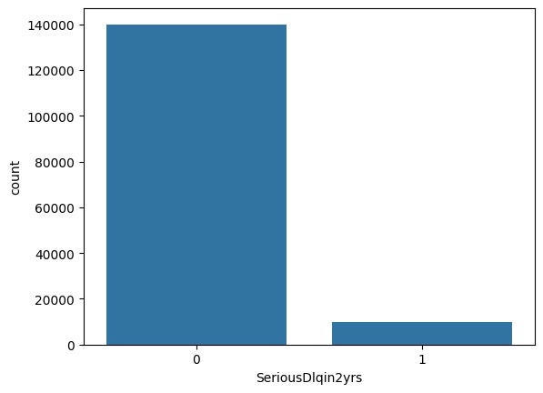

```python
sns.countplot(x  = "SeriousDlqin2yrs" , data = loans)
```

- No Outliers in this variable and Class imbalance exists

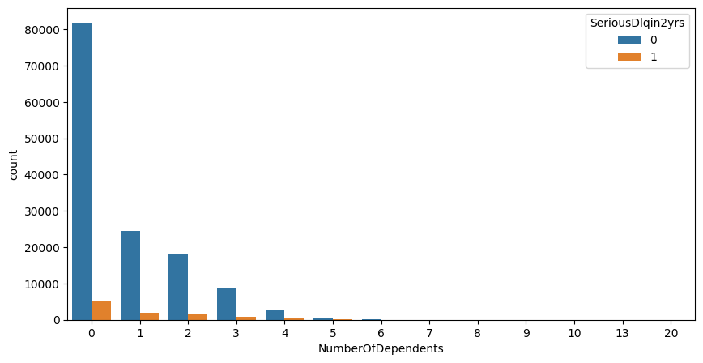

```python
plt.figure(figsize=(10,5))
sns.countplot(x='NumberOfDependents', hue = "SeriousDlqin2yrs" , data = loans) # class imbalance
plt.show()
```

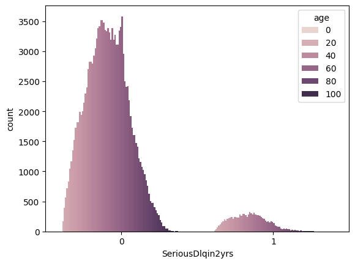

```python
sns.countplot(x = "SeriousDlqin2yrs" , hue = 'age', data = loans)
```

- Tip: create a rough colab worksheet copy this cell as well as other needed info for reference.

```python
loans.dtypes
```

|  | 0 |
| --- | --- |
| Sr_No | int64 |
| SeriousDlqin2yrs | int64 |
| monthly_utilization | float64 |
| age | int64 |
| NumberOfTime30-59DaysPastDueNotWorse | int64 |
| DebtRatio | float64 |
| MonthlyIncome | float64 |
| NumberOfOpenCreditLinesAndLoans | int64 |
| NumberOfTimes90DaysLate | int64 |
| NumberRealEstateLoansOrLines | int64 |
| NumberOfTime60-89DaysPastDueNotWorse | int64 |
| NumberOfDependents | Int64 |

**dtype:** object

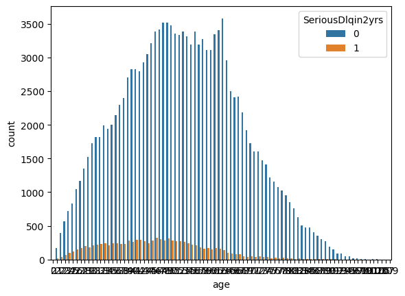

```python
sns.countplot(hue = "SeriousDlqin2yrs" , x = 'age', data = loans)
```

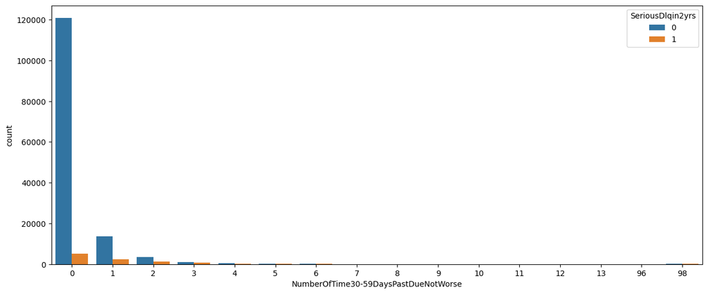

```python
plt.figure(figsize=(15,6))
sns.countplot(hue = "SeriousDlqin2yrs" , x = 'NumberOfTime30-59DaysPastDueNotWorse', data = loans)
plt.show()
```

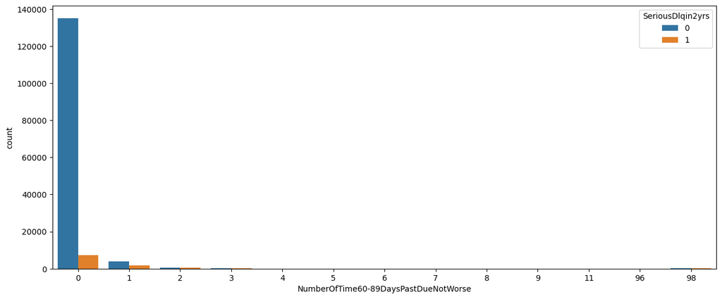

```python
plt.figure(figsize=(15,6))
sns.countplot(hue = "SeriousDlqin2yrs" , x = 'NumberOfTime60-89DaysPastDueNotWorse', data = loans)
plt.show()
```

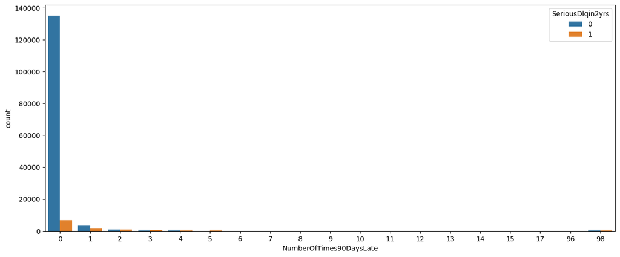

```python
plt.figure(figsize=(15,6))
sns.countplot(hue = "SeriousDlqin2yrs" , x = 'NumberOfTimes90DaysLate', data = loans)
plt.show()
```

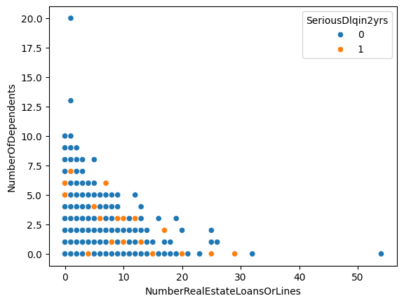

```python
sns.scatterplot(data=loans, x="NumberRealEstateLoansOrLines", y="NumberOfDependents", hue="SeriousDlqin2yrs")
```

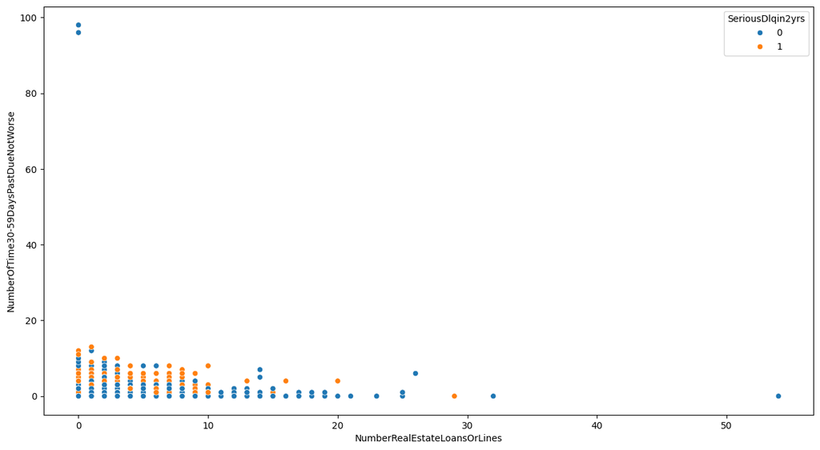

```python
plt.figure(figsize=(15,8))
sns.scatterplot(data=loans, x="NumberRealEstateLoansOrLines", y="NumberOfTime30-59DaysPastDueNotWorse", hue="SeriousDlqin2yrs")
plt.show()
```

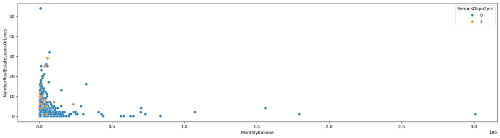

```python
plt.figure(figsize=(20,5))
sns.scatterplot(data=loans, y="NumberRealEstateLoansOrLines", x="MonthlyIncome", hue="SeriousDlqin2yrs")
plt.show()
```

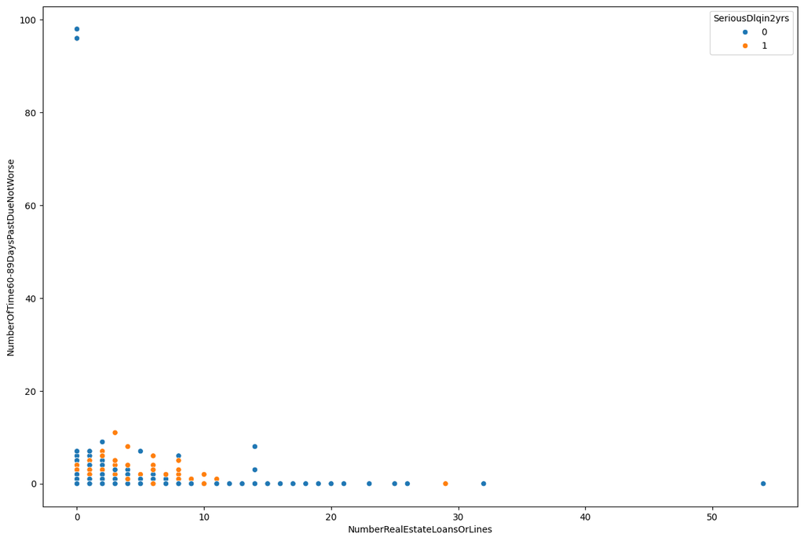

```python
plt.figure(figsize=(15,10))
sns.scatterplot(data=loans, x="NumberRealEstateLoansOrLines", y="NumberOfTime60-89DaysPastDueNotWorse", hue="SeriousDlqin2yrs")
plt.show()
```

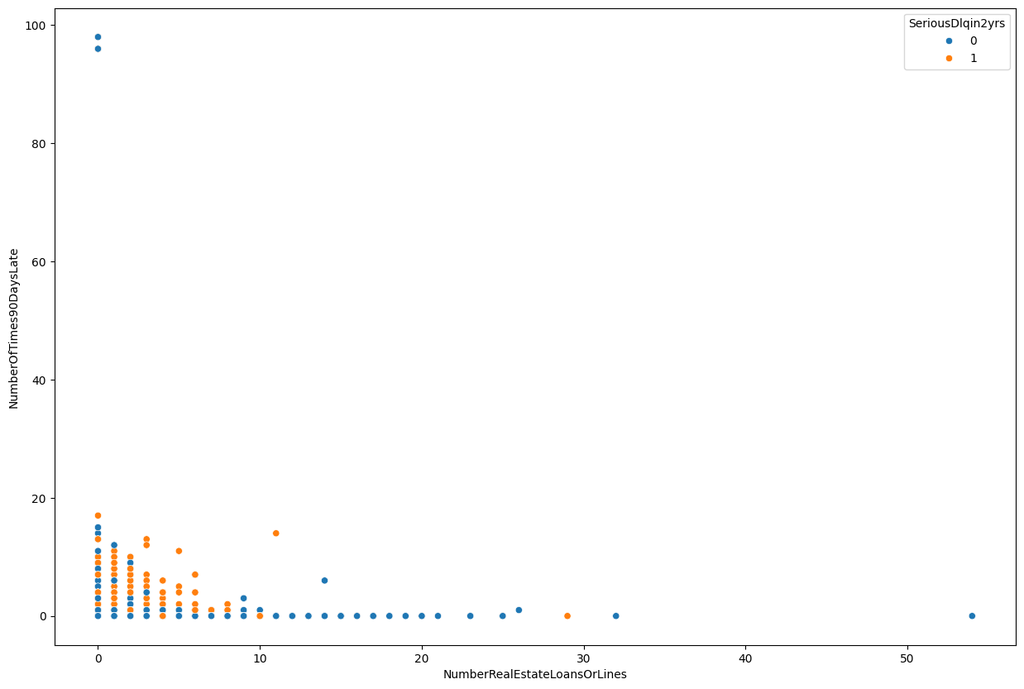

```python
plt.figure(figsize=(15,10))
sns.scatterplot(data=loans, x="NumberRealEstateLoansOrLines", y="NumberOfTimes90DaysLate", hue="SeriousDlqin2yrs")
plt.show()
```

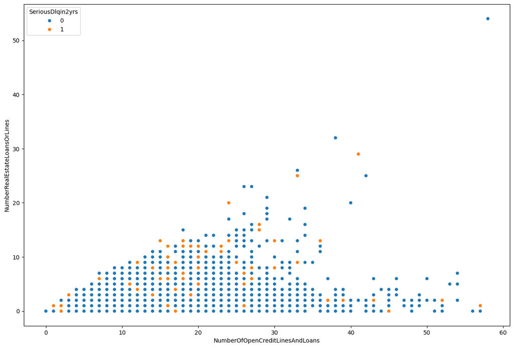

```python
plt.figure(figsize=(15,10))
sns.scatterplot(data=loans, y="NumberRealEstateLoansOrLines", x="NumberOfOpenCreditLinesAndLoans", hue="SeriousDlqin2yrs")
plt.show()
```

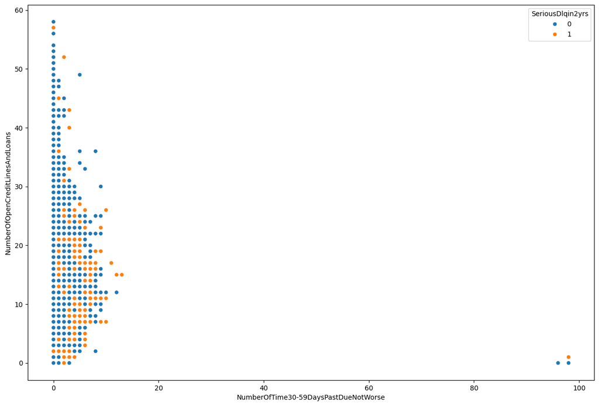

```python
plt.figure(figsize=(15,10))
sns.scatterplot(data=loans, x="NumberOfTime30-59DaysPastDueNotWorse", y="NumberOfOpenCreditLinesAndLoans", hue="SeriousDlqin2yrs") # redraw graph after cleaning outliers
plt.show()
```

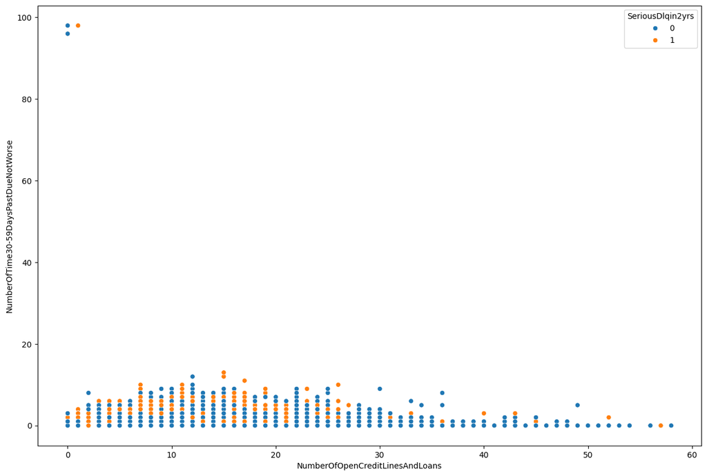

```python
plt.figure(figsize=(15,10))
sns.scatterplot(data=loans, y="NumberOfTime30-59DaysPastDueNotWorse", x="NumberOfOpenCreditLinesAndLoans", hue="SeriousDlqin2yrs") # redraw graph after cleaning outliers
plt.show()
```

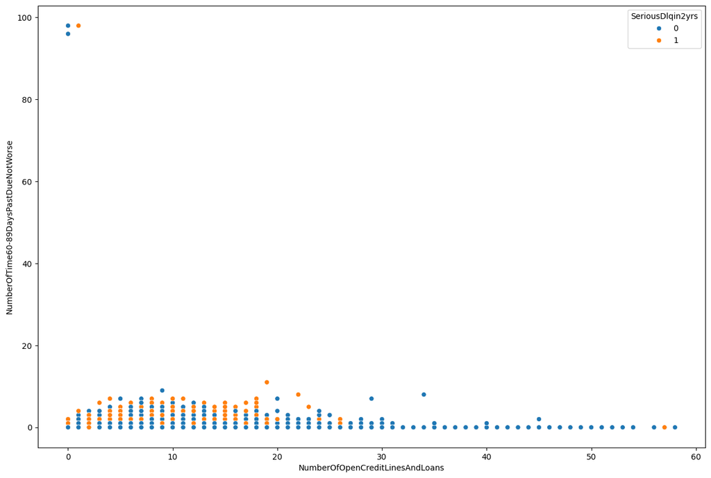

```python
plt.figure(figsize=(15,10))
sns.scatterplot(data=loans, y="NumberOfTime60-89DaysPastDueNotWorse", x="NumberOfOpenCreditLinesAndLoans", hue="SeriousDlqin2yrs") # redraw graph after cleaning outliers
plt.show()
```

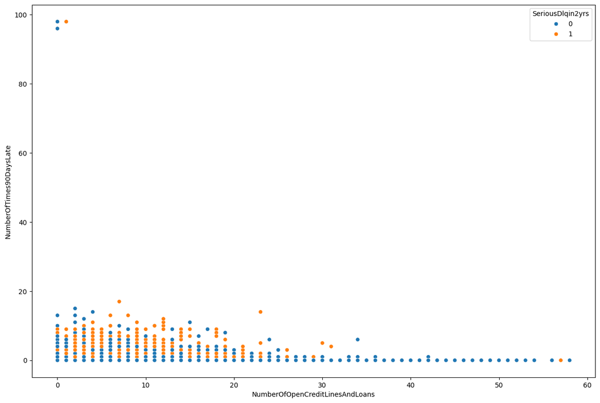

```python
plt.figure(figsize=(15,10))
sns.scatterplot(data=loans, y="NumberOfTimes90DaysLate", x="NumberOfOpenCreditLinesAndLoans", hue="SeriousDlqin2yrs") # redraw graph after cleaning outliers
plt.show()
```

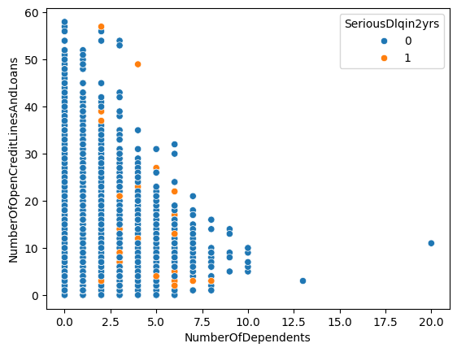

```python
sns.scatterplot(data=loans, x="NumberOfDependents", y="NumberOfOpenCreditLinesAndLoans", hue="SeriousDlqin2yrs") # redraw graph after cleaning outliers
```

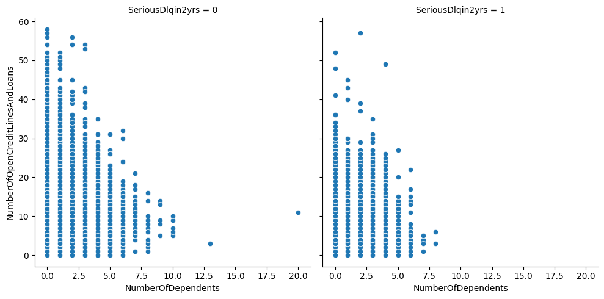

```python
sns.relplot(
    data=loans, x="NumberOfDependents", y="NumberOfOpenCreditLinesAndLoans", col="SeriousDlqin2yrs",
    kind="scatter"
)
```

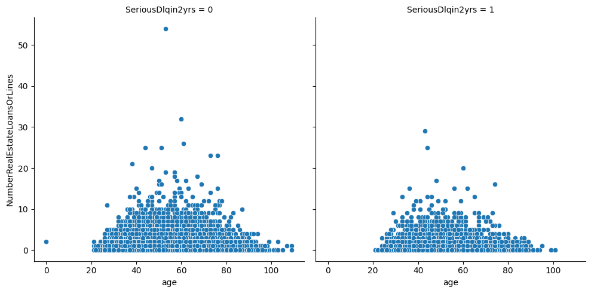

```python
sns.relplot(
    data=loans, x="age", y="NumberRealEstateLoansOrLines", col="SeriousDlqin2yrs",# hue = "age",
    kind="scatter"
)
```

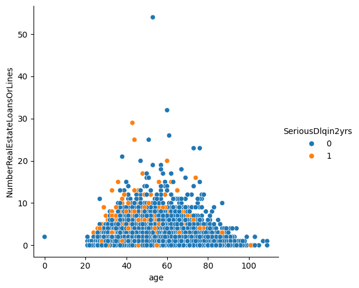

```python
plt.figure(figsize=(20,10))# this doesnt work
sns.relplot(data=loans, x="age", y="NumberRealEstateLoansOrLines", hue="SeriousDlqin2yrs")
plt.show()
```

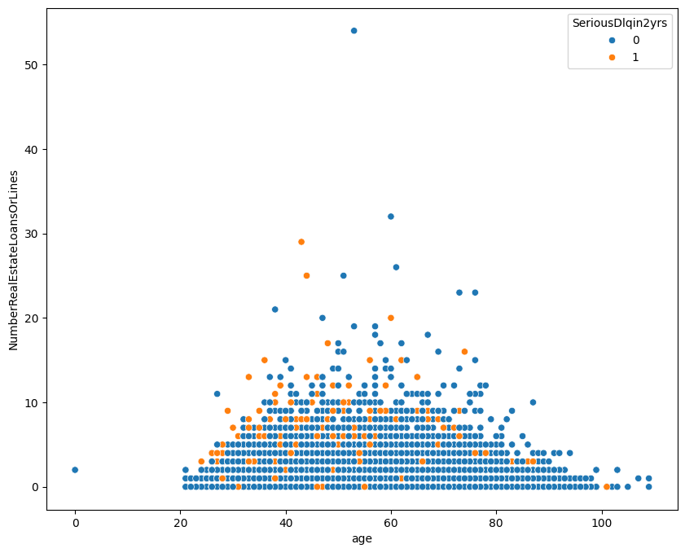

```python
plt.figure(figsize=(10,8))# this doesnt work
sns.scatterplot(data=loans, x="age", y="NumberRealEstateLoansOrLines", hue="SeriousDlqin2yrs")
plt.show()
```

## Age

```python
print(loans['age'].nunique())
```

```
86
```

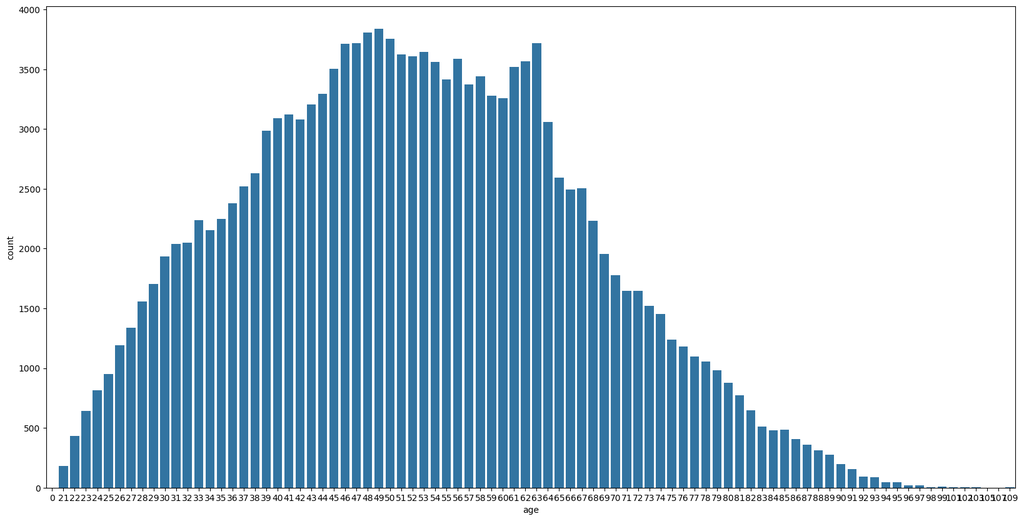

```python
plt.figure(figsize=(20,10))# this doesnt work
sns.countplot(loans, x="age")#,  hue="SeriousDlqin2yrs")#y="body_mass_g",
plt.show()
```

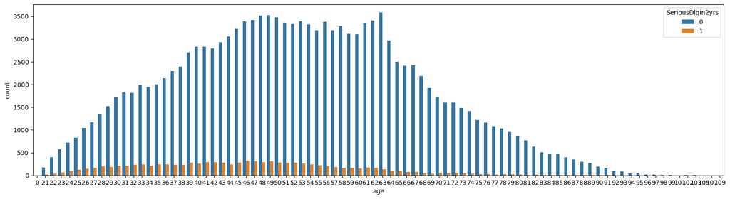

```python
plt.figure(figsize=(20,5))# this doesnt work
sns.countplot(loans, x="age",  hue="SeriousDlqin2yrs")#,multiple="stack")#y="body_mass_g",
plt.show()
```

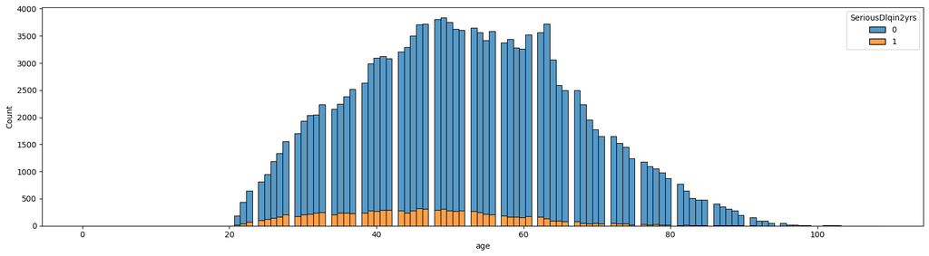

```python
plt.figure(figsize=(20,5))
sns.histplot(loans, x="age",  hue="SeriousDlqin2yrs",multiple="stack")#y="body_mass_g",
plt.show()
```

```python
loans.loc[loans['age']<20].value_counts().sum()
```

```
1
```

```python
loans['NumberOfTime30-59DaysPastDueNotWorse'].value_counts()
```

| NumberOfTime30-59DaysPastDueNotWorse | count |
| --- | --- |
| 0 | 126018 |
| 1 | 16033 |
| 2 | 4598 |
| 3 | 1754 |
| 4 | 747 |
| 5 | 342 |
| 98 | 264 |
| 6 | 140 |
| 7 | 54 |
| 8 | 25 |
| 9 | 12 |
| 96 | 5 |
| 10 | 4 |
| 12 | 2 |
| 13 | 1 |
| 11 | 1 |

**dtype:** int64

## 1 month delay

```python
print(loans['NumberOfTime30-59DaysPastDueNotWorse'].nunique())
```

```
16
```

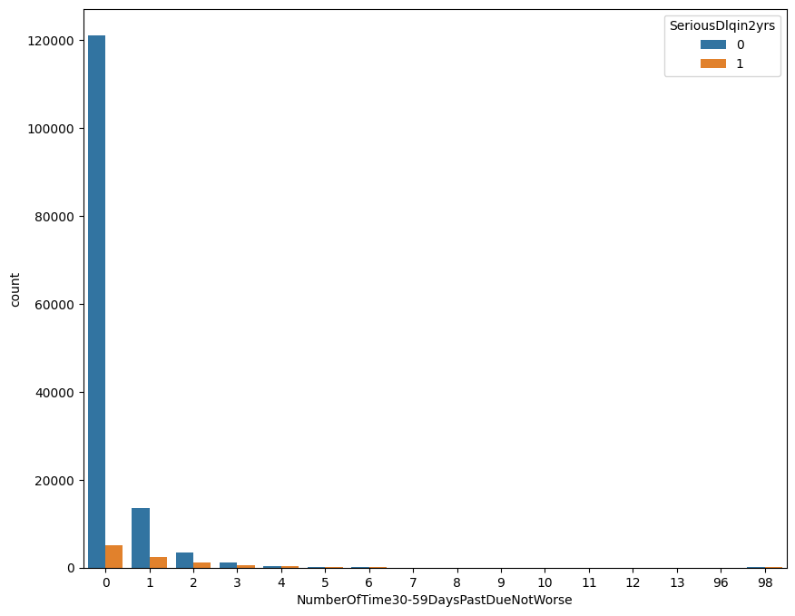

```python
plt.figure(figsize=(10,8))# this doesnt work
sns.countplot(loans, x="NumberOfTime30-59DaysPastDueNotWorse",  hue="SeriousDlqin2yrs")#,multiple="stack")#y="body_mass_g",
plt.show()
```

```python
loans['NumberOfTime30-59DaysPastDueNotWorse'].value_counts()
```

| NumberOfTime30-59DaysPastDueNotWorse | count |
| --- | --- |
| 0 | 126018 |
| 1 | 16033 |
| 2 | 4598 |
| 3 | 1754 |
| 4 | 747 |
| 5 | 342 |
| 98 | 264 |
| 6 | 140 |
| 7 | 54 |
| 8 | 25 |
| 9 | 12 |
| 96 | 5 |
| 10 | 4 |
| 12 | 2 |
| 13 | 1 |
| 11 | 1 |

**dtype:** int64

## Number of open credit loans

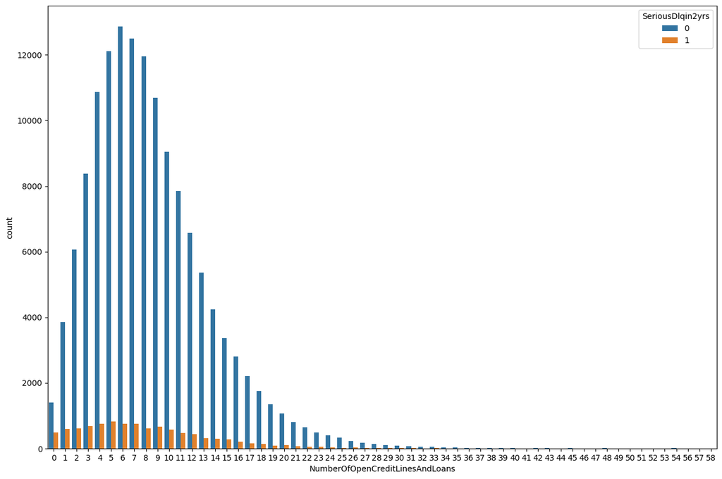

```python
plt.figure(figsize=(15,10))# this doesnt work
sns.countplot(loans, x="NumberOfOpenCreditLinesAndLoans",  hue="SeriousDlqin2yrs")#,multiple="stack")#y="body_mass_g",
plt.show()
```

```python
loans['NumberOfOpenCreditLinesAndLoans'].value_counts(sort=True)
```

| NumberOfOpenCreditLinesAndLoans | count |
| --- | --- |
| 6 | 13614 |
| 7 | 13245 |
| 5 | 12931 |
| 8 | 12562 |
| 4 | 11609 |
| 9 | 11355 |
| 10 | 9624 |
| 3 | 9058 |
| 11 | 8321 |
| 12 | 7005 |
| 2 | 6666 |
| 13 | 5667 |
| 14 | 4546 |
| 1 | 4438 |
| 15 | 3645 |
| 16 | 3000 |
| 17 | 2370 |
| 0 | 1888 |
| 18 | 1874 |
| 19 | 1433 |
| 20 | 1169 |
| 21 | 864 |
| 22 | 685 |
| 23 | 533 |
| 24 | 422 |
| 25 | 337 |
| 26 | 239 |
| 27 | 194 |
| 28 | 150 |
| 29 | 114 |
| 30 | 88 |
| 31 | 74 |
| 32 | 52 |
| 33 | 47 |
| 34 | 35 |
| 35 | 27 |
| 36 | 18 |
| 38 | 13 |
| 40 | 10 |
| 39 | 9 |
| 42 | 8 |
| 45 | 8 |
| 43 | 8 |
| 37 | 7 |
| 48 | 6 |
| 49 | 4 |
| 54 | 4 |
| 41 | 4 |
| 52 | 3 |
| 46 | 3 |
| 57 | 2 |
| 51 | 2 |
| 56 | 2 |
| 47 | 2 |
| 50 | 2 |
| 44 | 2 |
| 58 | 1 |
| 53 | 1 |

**dtype:** int64

## 3 month late

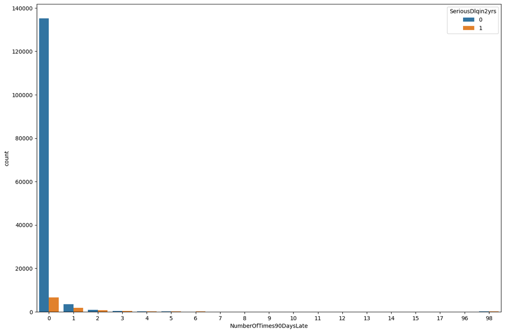

```python
plt.figure(figsize=(15,10))# this doesnt work
sns.countplot(loans, x="NumberOfTimes90DaysLate",  hue="SeriousDlqin2yrs")#,multiple="stack")#y="body_mass_g",
plt.show()
```

```python
loans['NumberOfTimes90DaysLate'].value_counts()
```

| NumberOfTimes90DaysLate | count |
| --- | --- |
| 0 | 141662 |
| 1 | 5243 |
| 2 | 1555 |
| 3 | 667 |
| 4 | 291 |
| 98 | 264 |
| 5 | 131 |
| 6 | 80 |
| 7 | 38 |
| 8 | 21 |
| 9 | 19 |
| 10 | 8 |
| 96 | 5 |
| 11 | 5 |
| 13 | 4 |
| 15 | 2 |
| 14 | 2 |
| 12 | 2 |
| 17 | 1 |

**dtype:** int64

## number of real estate loans

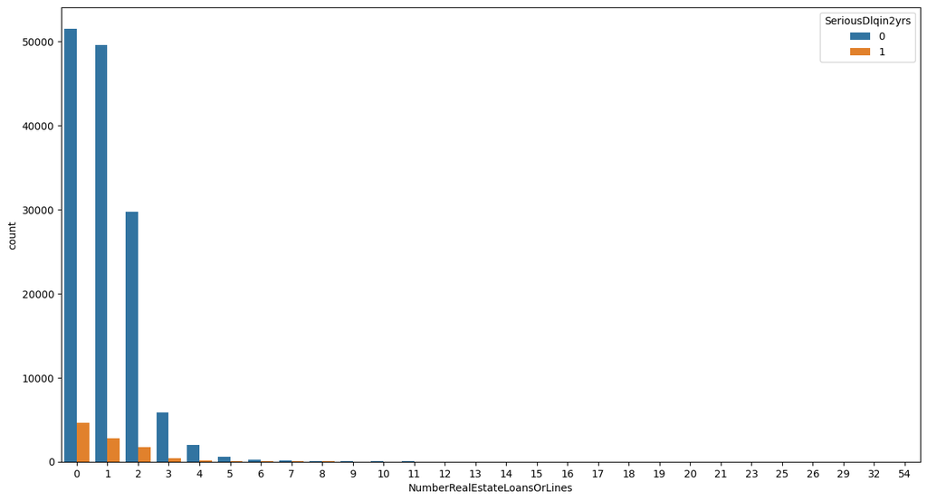

```python
plt.figure(figsize=(15,8))# this doesnt work
sns.countplot(loans, x='NumberRealEstateLoansOrLines',  hue="SeriousDlqin2yrs")#,multiple="stack")#y="body_mass_g",
plt.show()
```

```python
loans['NumberRealEstateLoansOrLines'].value_counts()
```

| NumberRealEstateLoansOrLines | count |
| --- | --- |
| 0 | 56188 |
| 1 | 52338 |
| 2 | 31522 |
| 3 | 6300 |
| 4 | 2170 |
| 5 | 689 |
| 6 | 320 |
| 7 | 171 |
| 8 | 93 |
| 9 | 78 |
| 10 | 37 |
| 11 | 23 |
| 12 | 18 |
| 13 | 15 |
| 15 | 7 |
| 14 | 7 |
| 17 | 4 |
| 16 | 4 |
| 25 | 3 |
| 18 | 2 |
| 23 | 2 |
| 19 | 2 |
| 20 | 2 |
| 26 | 1 |
| 54 | 1 |
| 21 | 1 |
| 29 | 1 |
| 32 | 1 |

**dtype:** int64

## 2 month delay

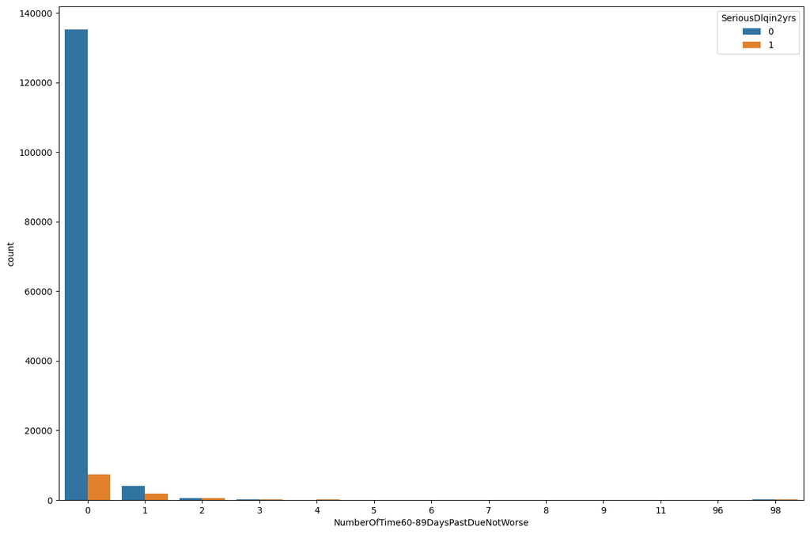

```python
plt.figure(figsize=(15,10))# this doesnt work
sns.countplot(loans, x='NumberOfTime60-89DaysPastDueNotWorse',  hue="SeriousDlqin2yrs")#,multiple="stack")#y="body_mass_g",
plt.show()
```

```python
loans['NumberOfTime60-89DaysPastDueNotWorse'].value_counts()
```

| NumberOfTime60-89DaysPastDueNotWorse | count |
| --- | --- |
| 0 | 142396 |
| 1 | 5731 |
| 2 | 1118 |
| 3 | 318 |
| 98 | 264 |
| 4 | 105 |
| 5 | 34 |
| 6 | 16 |
| 7 | 9 |
| 96 | 5 |
| 8 | 2 |
| 11 | 1 |
| 9 | 1 |

**dtype:** int64

## dependents.

```python
loans['NumberOfDependents'].isnull().any()
```

```
True
```

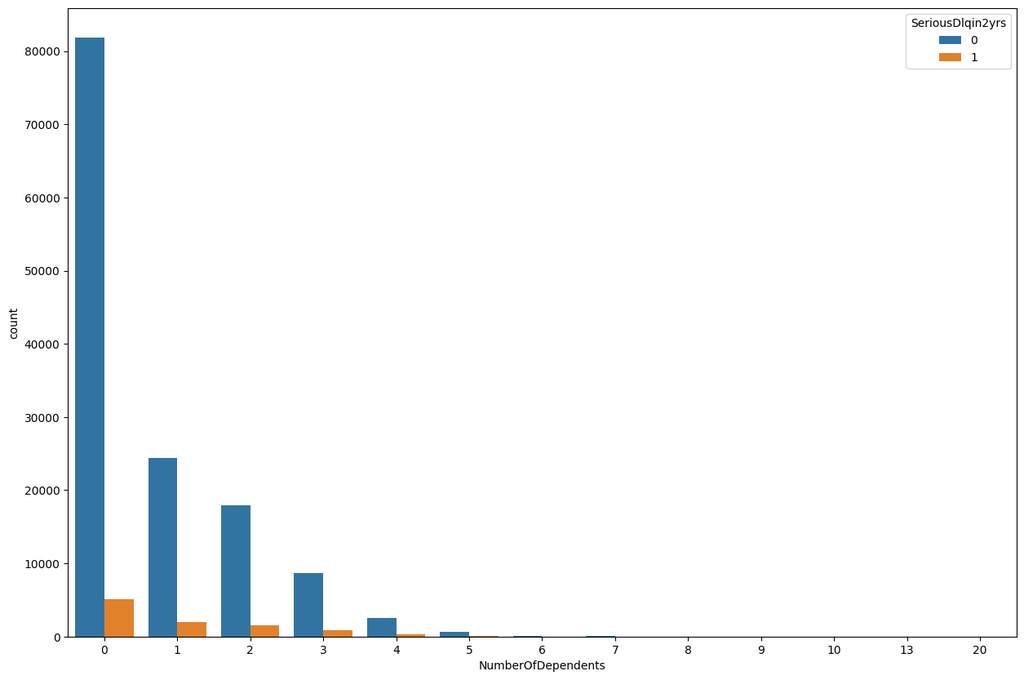

```python
plt.figure(figsize=(15,10))# this doesnt work
sns.countplot(loans, x='NumberOfDependents',  hue="SeriousDlqin2yrs")#,multiple="stack")#y="body_mass_g",
plt.show()
```

```python
loans['NumberOfDependents'].value_counts()
```

| NumberOfDependents | count |
| --- | --- |
| 0 | 86902 |
| 1 | 26316 |
| 2 | 19522 |
| 3 | 9483 |
| 4 | 2862 |
| 5 | 746 |
| 6 | 158 |
| 7 | 51 |
| 8 | 24 |
| 10 | 5 |
| 9 | 5 |
| 20 | 1 |
| 13 | 1 |

**dtype:** Int64